# Data Imbalance - Health Insurance

*By: Francisco da Ana (up202108762)*

For this assignement related to **Imbalaced Data**, I will be using the Health Insurance dataset already explored in the first and second assignements (Data Profiling & Data Complexity).

From the suggested tasks for this assignement, I chose project **B**:

performance metric(s) to optimize ... Then, select a few classification methods ... Finally, apply different techniques for addressing the class imbalance issue"

First, let's remember the dataset characteristics and the main objective of the dataset:

It contains 15 attributes (1 target and 14 features) and 72458 instances. The target variable is `health_ins`, which is a binary feature that indicates if the individual has health insurance or not. The dataset contains both numerical and categorical features.

The attributes are:

- *`unnamed`* | **numeric**: an index column
- `custid` | **text**: the unique ID of the customer
- `sex` | **categorical**: the gender of the customer
- `is_employed` | **boolean**: indicates whether the customer is employed or not
- `income` | **numeric**: numerical value representing the customer's income
- `marital_status` | **categorical**: the marital status of the customer
- `health_ins` | **boolean**: indicates whether the customer has health insurance or not. This can be the target variable in the context of a classification problem.
- `housing_type` | **categorical**: describes the situation of the customer's habitation
- `num_vehicles` | **numeric**: the number of vehicles the customer owns
- `age` | **numeric**: the age of the customer in years
- `state_of_res` | **text**: the US state where the customer resides
- `code_column` | **numeric**: likely a categorical or code-based feature (potentially related to location or demographics).
- `gas_usage` | **numeric**: a measure of the customer's gas usage
- `rooms` | **numeric**: the number of rooms in the customer's house
- `recent_move_b` | **boolean**: indicator if the customer has recently moved

```python
import numpy as np
import pandas as pd
import seaborn as sns
import problexity.classification as pbx
from sklearn.preprocessing import MinMaxScaler, LabelEncoder
from sklearn.model_selection import train_test_split
from sklearn.tree import DecisionTreeClassifier
from sklearn.neighbors import KNeighborsClassifier
from sklearn.ensemble import RandomForestClassifier
from sklearn.metrics import confusion_matrix, ConfusionMatrixDisplay, accuracy_score, f1_score, recall_score, precision_score
import matplotlib.pyplot as plt
from imblearn.over_sampling import SMOTE, RandomOverSampler, BorderlineSMOTE, ADASYN, SVMSMOTE
from imblearn.combine import SMOTEENN, SMOTETomek
```

## Remembering the previous analysis

In a first step of this assignement, I will remember the main conclusions from the previous assignements and then I will proceed with the analysis of the impact of the data imbalance in the classification task.

### Data Profiling & Preprocessing

```python
df = pd.read_csv('data.csv')
df.head()
```

|  | Unnamed: 0 | custid | sex | is_employed | income | marital_status | health_ins | housing_type | num_vehicles | age | state_of_res | code_column | gas_usage | rooms | recent_move_b |
| --- | --- | --- | --- | --- | --- | --- | --- | --- | --- | --- | --- | --- | --- | --- | --- |
| 0 | 7 | 000006646_03 | Male | True | 22000.0 | Never married | True | Homeowner free and clear | 0.0 | 24 | Alabama | 1047 | 210.0 | 3 | F |
| 1 | 8 | 000007827_01 | Female | NaN | 23200.0 | Divorced/Separated | True | Rented | 0.0 | 82 | Alabama | 1047 | 3.0 | 6 | T |
| 2 | 9 | 000008359_04 | Female | True | 21000.0 | Never married | True | Homeowner with mortgage/loan | 2.0 | 31 | Alabama | 1047 | 40.0 | 3 | F |
| 3 | 10 | 000008529_01 | Female | NaN | 37770.0 | Widowed | True | Homeowner free and clear | 1.0 | 93 | Alabama | 1047 | 120.0 | 2 | F |
| 4 | 11 | 000008744_02 | Male | True | 39000.0 | Divorced/Separated | True | Rented | 2.0 | 67 | Alabama | 1047 | 3.0 | 2 | F |

One of the problems we identified in the first assignement was the presence of unique identifiers in the dataset, such as the `custid` and *`unnamed`* columns. These columns are not relevant for the analysis and should be removed, since they are not useful for finding patterns in the data.

```python
# 'Unnamed: 0', 'custid' must be removed
df = df.drop(['Unnamed: 0', 'custid'], axis=1)
df.shape
```

```
(72458, 13)
```

Now let's treat the missing values.

```python
df.isnull().sum()
```

```
sex                   0
is_employed       25515
income                0
marital_status        0
health_ins            0
housing_type       1686
num_vehicles       1686
age                   0
state_of_res          0
code_column           0
gas_usage          1686
rooms                 0
recent_move_b      1687
dtype: int64
```

```python
df['is_employed'].value_counts(dropna=False)
```

```
is_employed
True     44630
NaN      25515
False     2313
Name: count, dtype: int64
```

`Nan` values in column `is_employed` mean individuals that do not belong to the workforce. We will replace these values with `False`.

```python
df['is_employed'] = df['is_employed'].fillna(0)
df['is_employed'].value_counts(dropna=False)
```

```
is_employed
True    44630
0       27828
Name: count, dtype: int64
```

```python
num = df[df.isnull().any(axis=1)].shape[0]
print(f'{num} rows have missing values.')
print(f'Approx. {num/df.shape[0]*100:.2f}% of the orignal dataset.')
```

```
1687 rows have missing values.
Approx. 2.33% of the orignal dataset.
```

Seems that all missing values are distributed in the same 1687 rows. Since the focus of this assignement is not on missing data, I will simply remove these rows.

```python
df = df.dropna()
df.shape
```

```
(70771, 13)
```

```python
# How many values from code column are associated with each state?
code_per_state = df.groupby('state_of_res')['code_column'].nunique()
print(max(code_per_state), min(code_per_state))
print(list(df['code_column'].unique()))
```

```
1 1
[np.int64(1047), np.int64(162), np.int64(1534), np.int64(653), np.int64(8962), np.int64(1291), np.int64(832), np.int64(204), np.int64(170), np.int64(4979), np.int64(2198), np.int64(354), np.int64(333), np.int64(2925), np.int64(1467), np.int64(706), np.int64(647), np.int64(935), np.int64(1104), np.in…
```

There are also redundant columns like `code_column`, which encodes the `state_of_res` column. We can remove one of them. I prefer to keep the `state_of_res` column and then enconde it to numerical values with 1 unit of difference between each state.

```python
df.drop('code_column', axis=1, inplace=True)
df.shape
```

```
(70771, 12)
```

Another issue is the presence of outliers for variables `age`, `income` and `gas_usage`.

```python
# For variable 'age', truncate values to [21-99]. Values outside this range will be replaced to th closest endpoint.
print(f'Max age: {df['age'].max()} | Min age: {df['age'].min()}')
df['age'] = df['age'].clip(lower=21, upper=99)
print(f'Max age: {df['age'].max()} | Min age: {df['age'].min()}')
print(df['age'].describe())
```

```
Max age: 120 | Min age: 0
Max age: 99 | Min age: 21
count    70771.000000
mean        49.194317
std         17.746154
min         21.000000
25%         34.000000
50%         48.000000
75%         62.000000
max         99.000000
Name: age, dtype: float64
```

```python
# scale 'age' feature to 0-1 and round to 4 decimal places (people with similar ages will be grouped together)
scaler = MinMaxScaler()
df['age'] = scaler.fit_transform(df[['age']]).round(4)*10
df['age'].describe()
```

```
count    70771.000000
mean         3.614646
std          2.275162
min          0.000000
25%          1.667000
50%          3.462000
75%          5.256000
max         10.000000
Name: age, dtype: float64
```

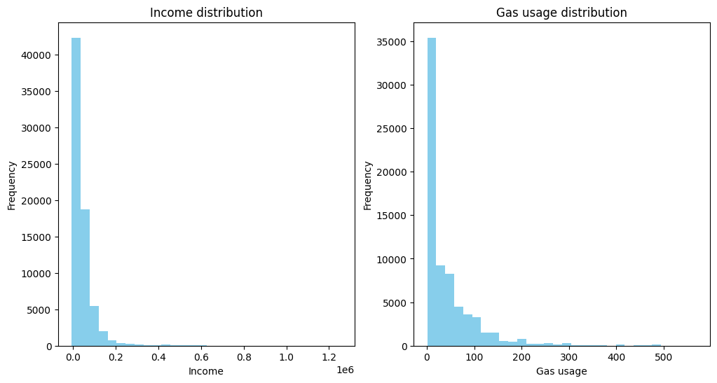

```python
# Plot distribution of 'income' and 'gas_usage'
fig, ax = plt.subplots(1, 2, figsize=(12, 6))
ax[0].hist(df['income'], bins=30, color='skyblue')
ax[0].set_title('Income distribution')
ax[0].set_xlabel('Income')
ax[0].set_ylabel('Frequency')

ax[1].hist(df['gas_usage'], bins=30, color='skyblue')
ax[1].set_title('Gas usage distribution')
ax[1].set_xlabel('Gas usage')
ax[1].set_ylabel('Frequency')

plt.show()
```

These attributes are highly right skewed, so I will use logaritmic transformation to reduce the skewness.

```python
print(f'Before:\n{df[['income', 'gas_usage']].describe()}')
df['income'] = np.log1p(abs(df['income'])+0.001).round(4)
df['gas_usage'] = np.log1p(df['gas_usage']).round(4)
print(f'After:\n{df[['income', 'gas_usage']].describe()}')
```

```
Before:
             income     gas_usage
count  7.077100e+04  70771.000000
mean   4.263217e+04     41.231041
std    5.864206e+04     63.149606
min   -6.900000e+03      1.000000
25%    1.130000e+04      3.000000
50%    2.749000e+04     10.000000
75%    5.206000e+04     60.000000
max    1.257000e+06    570.000000
After:
             income     gas_usage
count  70771.000000  70771.000000
mean       9.341168      2.721067
std        3.066347      1.495301
min        0.001000      0.693100
25%        9.332600      1.386300
50%       10.221600      2.397900
75%       10.860200      4.110900
max       14.044200      6.347400
```

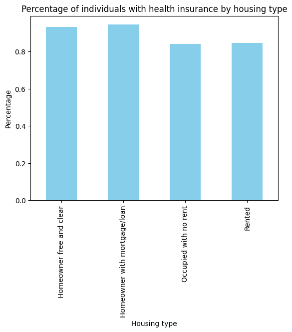

```python
# Plot percetage of individuals with 'health_ins' by 'housing_type'
df.groupby('housing_type')['health_ins'].mean().plot(kind='bar', color='skyblue')
plt.title('Percentage of individuals with health insurance by housing type')
plt.xlabel('Housing type')
plt.ylabel('Percentage')
plt.show()
```

```python
# Join categories "Homewoner free and clear" and "Homeowner with mortgage/loan" from 'housing_type' into 0
df['housing_type'] = df['housing_type'].replace(['Homeowner free and clear', 'Homeowner with mortgage/loan'], 0)
# Join categories "Occupied with no rent" and "Rented" from 'housing_type' into 1
df['housing_type'] = df['housing_type'].replace(['Occupied with no rent', 'Rented'], 1)

df['housing_type'].value_counts()
```

```
housing_type
0    47695
1    23076
Name: count, dtype: int64
```

```python
df.head(10)
```

|  | sex | is_employed | income | marital_status | health_ins | housing_type | num_vehicles | age | state_of_res | gas_usage | rooms | recent_move_b |
| --- | --- | --- | --- | --- | --- | --- | --- | --- | --- | --- | --- | --- |
| 0 | Male | True | 9.9988 | Never married | True | 0 | 0.0 | 0.385 | Alabama | 5.3519 | 3 | F |
| 1 | Female | 0 | 10.0520 | Divorced/Separated | True | 1 | 0.0 | 7.821 | Alabama | 1.3863 | 6 | T |
| 2 | Female | True | 9.9523 | Never married | True | 0 | 2.0 | 1.282 | Alabama | 3.7136 | 3 | F |
| 3 | Female | 0 | 10.5393 | Widowed | True | 0 | 1.0 | 9.231 | Alabama | 4.7958 | 2 | F |
| 4 | Male | True | 10.5713 | Divorced/Separated | True | 1 | 2.0 | 5.897 | Alabama | 1.3863 | 2 | F |
| 5 | Male | 0 | 9.3148 | Married | True | 0 | 2.0 | 7.051 | Alabama | 5.3033 | 6 | F |
| 6 | Female | True | 10.1582 | Married | False | 1 | 2.0 | 0.641 | Alabama | 1.3863 | 3 | F |
| 7 | Female | 0 | 10.4516 | Married | True | 0 | 2.0 | 6.667 | Alabama | 3.9318 | 5 | F |
| 8 | Female | True | 10.1267 | Never married | True | 0 | 5.0 | 0.769 | Alabama | 1.3863 | 4 | F |
| 9 | Male | True | 10.3482 | Married | True | 0 | 3.0 | 4.231 | Alabama | 3.0445 | 6 | F |

Categorical columns must be encoded to numerical values.

```python
# label encoding
cols_label_encode = ['sex','is_employed','state_of_res','health_ins','recent_move_b','housing_type']
label_encoder = LabelEncoder()
for col in cols_label_encode:
    df[col] = label_encoder.fit_transform(df[col])

df.head(10)
```

|  | sex | is_employed | income | marital_status | health_ins | housing_type | num_vehicles | age | state_of_res | gas_usage | rooms | recent_move_b |
| --- | --- | --- | --- | --- | --- | --- | --- | --- | --- | --- | --- | --- |
| 0 | 1 | 1 | 9.9988 | Never married | 1 | 0 | 0.0 | 0.385 | 0 | 5.3519 | 3 | 0 |
| 1 | 0 | 0 | 10.0520 | Divorced/Separated | 1 | 1 | 0.0 | 7.821 | 0 | 1.3863 | 6 | 1 |
| 2 | 0 | 1 | 9.9523 | Never married | 1 | 0 | 2.0 | 1.282 | 0 | 3.7136 | 3 | 0 |
| 3 | 0 | 0 | 10.5393 | Widowed | 1 | 0 | 1.0 | 9.231 | 0 | 4.7958 | 2 | 0 |
| 4 | 1 | 1 | 10.5713 | Divorced/Separated | 1 | 1 | 2.0 | 5.897 | 0 | 1.3863 | 2 | 0 |
| 5 | 1 | 0 | 9.3148 | Married | 1 | 0 | 2.0 | 7.051 | 0 | 5.3033 | 6 | 0 |
| 6 | 0 | 1 | 10.1582 | Married | 0 | 1 | 2.0 | 0.641 | 0 | 1.3863 | 3 | 0 |
| 7 | 0 | 0 | 10.4516 | Married | 1 | 0 | 2.0 | 6.667 | 0 | 3.9318 | 5 | 0 |
| 8 | 0 | 1 | 10.1267 | Never married | 1 | 0 | 5.0 | 0.769 | 0 | 1.3863 | 4 | 0 |
| 9 | 1 | 1 | 10.3482 | Married | 1 | 0 | 3.0 | 4.231 | 0 | 3.0445 | 6 | 0 |

```python
# one hot encoding
cols_one_hot_encode = ['marital_status']
df = pd.get_dummies(df, columns=cols_one_hot_encode, dummy_na=False)
dummies = list(filter(lambda x: x.startswith(tuple(cols_one_hot_encode)), df.columns))
for col in dummies:
    df[col] = label_encoder.fit_transform(df[col])

df.head(10)
```

|  | sex | is_employed | income | health_ins | housing_type | num_vehicles | age | state_of_res | gas_usage | rooms | recent_move_b | marital_status_Divorced/Separated | marital_status_Married | marital_status_Never married | marital_status_Widowed |
| --- | --- | --- | --- | --- | --- | --- | --- | --- | --- | --- | --- | --- | --- | --- | --- |
| 0 | 1 | 1 | 9.9988 | 1 | 0 | 0.0 | 0.385 | 0 | 5.3519 | 3 | 0 | 0 | 0 | 1 | 0 |
| 1 | 0 | 0 | 10.0520 | 1 | 1 | 0.0 | 7.821 | 0 | 1.3863 | 6 | 1 | 1 | 0 | 0 | 0 |
| 2 | 0 | 1 | 9.9523 | 1 | 0 | 2.0 | 1.282 | 0 | 3.7136 | 3 | 0 | 0 | 0 | 1 | 0 |
| 3 | 0 | 0 | 10.5393 | 1 | 0 | 1.0 | 9.231 | 0 | 4.7958 | 2 | 0 | 0 | 0 | 0 | 1 |
| 4 | 1 | 1 | 10.5713 | 1 | 1 | 2.0 | 5.897 | 0 | 1.3863 | 2 | 0 | 1 | 0 | 0 | 0 |
| 5 | 1 | 0 | 9.3148 | 1 | 0 | 2.0 | 7.051 | 0 | 5.3033 | 6 | 0 | 0 | 1 | 0 | 0 |
| 6 | 0 | 1 | 10.1582 | 0 | 1 | 2.0 | 0.641 | 0 | 1.3863 | 3 | 0 | 0 | 1 | 0 | 0 |
| 7 | 0 | 0 | 10.4516 | 1 | 0 | 2.0 | 6.667 | 0 | 3.9318 | 5 | 0 | 0 | 1 | 0 | 0 |
| 8 | 0 | 1 | 10.1267 | 1 | 0 | 5.0 | 0.769 | 0 | 1.3863 | 4 | 0 | 0 | 0 | 1 | 0 |
| 9 | 1 | 1 | 10.3482 | 1 | 0 | 3.0 | 4.231 | 0 | 3.0445 | 6 | 0 | 0 | 1 | 0 | 0 |

Is the data prepared to be used in the classification task? Well, let's take a last look... on the target variable.

```python
print(df['health_ins'].value_counts()/df.shape[0]*100)
positive_cases = df[df['health_ins'] == 1].shape[0]
negative_cases = df[df['health_ins'] == 0].shape[0]
print(f'Imbalance ratio: {round(positive_cases/negative_cases)}')
```

```
health_ins
1    90.910119
0     9.089881
Name: count, dtype: float64
Imbalance ratio: 10
```

```python
print(f'{len(df.columns)} columns: {list(df.columns)}')
```

```
15 columns: ['sex', 'is_employed', 'income', 'health_ins', 'housing_type', 'num_vehicles', 'age', 'state_of_res', 'gas_usage', 'rooms', 'recent_move_b', 'marital_status_Divorced/Separated', 'marital_status_Married', 'marital_status_Never married', 'marital_status_Widowed']
```

Our target variable is highly imbalanced, with a IR of around 10. Data complexity measure "Entropy of class proportions" is 0.561. A value like this for a binary classification problem indicates a considerable level of class imbalance that may require techniques to address the imbalance and ensure the model's performance is robust across both classes.

### Performance of some classifiers

Before treating the imbalance issue, let's apply 2 simple classifiers to the dataset and check their performance metrics. We will use the following classifiers:

- Decision Tree
- K-Nearest Neighbors

```python
target = 'health_ins'
X = df.drop(target, axis=1)
y = df[target]
X_train, X_test, y_train, y_test = train_test_split(X, y, test_size=0.3, random_state=42, shuffle=True)
```

For this dataset, in the previous assignement we verified the best F1 score is achieved for the following hyperparameters:

- **Decision Tree**: `max_depth=5`
- **K-Nearest Neighbors**: `n_neighbors=20`

#### Decision Tree

```python
imb_dt_max5 = DecisionTreeClassifier(max_depth=5, random_state=42)
imb_dt_max5.fit(X_train, y_train)
y_pred = imb_dt_max5.predict(X_test)
print(f'Accuracy: {round(accuracy_score(y_test, y_pred),4)} | F1: {round(f1_score(y_test, y_pred),4)}')
```

```
Accuracy: 0.9096 | F1: 0.9527
```

This seems very good! Accuracy rounds 91% and F1 95%. But let's see the confusion matrix.

```
Specificity: 0.0%
```

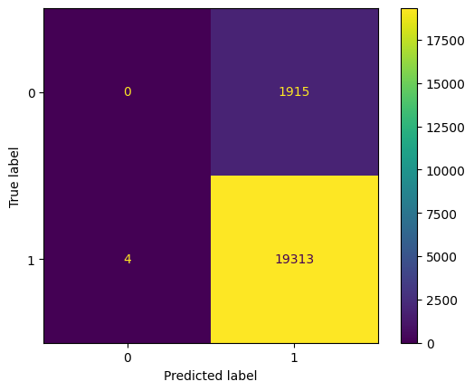

```python
cm_imb_dt_max5 = confusion_matrix(y_test, y_pred)
ConfusionMatrixDisplay(confusion_matrix=cm_imb_dt_max5).plot()
tp, tn, fp, fn = cm_imb_dt_max5[1,1], cm_imb_dt_max5[0,0], cm_imb_dt_max5[0,1], cm_imb_dt_max5[1,0]

# Specificity is the proportion of actual negative cases that are correctly identified.
spec = round(tn/(tn+fp),3)*100
print(f'Specificity: {spec}%')
```

The performance metrics are very misleading. The model is absolutely biased towards the majority class, since it basically classifies all cases as positive.

What if we we don't limit the tree's depth? Will the model overfit?

```python
imb_dt_nomax = DecisionTreeClassifier(random_state=42)
imb_dt_nomax.fit(X_train, y_train)
y_pred = imb_dt_nomax.predict(X_test)
print(f'Accuracy: {round(accuracy_score(y_test, y_pred),4)} | F1: {round(f1_score(y_test, y_pred),4)}')
```

```
Accuracy: 0.8461 | F1: 0.9148
```

Worse performance...?

```
Specificity: 22.0%
```

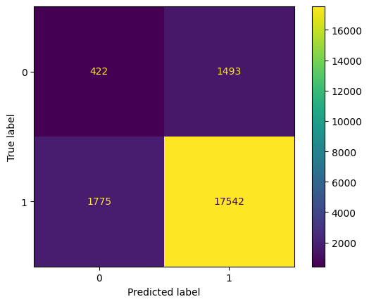

```python
cm_imb_dt_nomax = confusion_matrix(y_test, y_pred)
ConfusionMatrixDisplay(confusion_matrix=cm_imb_dt_nomax).plot()

tp, tn, fp, fn = cm_imb_dt_nomax[1,1], cm_imb_dt_nomax[0,0], cm_imb_dt_nomax[0,1], cm_imb_dt_nomax[1,0]
spec = round(tn/(tn+fp),3)*100
print(f'Specificity: {spec}%')
```

Even with "worse" metrics, the "overfitted" decision tree is more able of capturiing the minority class. There were 422 true negatives in the testing process, which is a huge improvement on the "optimized" tree, besides the lower accuracy and F1 score.

Specificity increased from absolute 0 to 22%, which is still very low, but it's a start.

#### K-Nearest Neighbors

How will a KNN classifier perform?

```python
imb_knn_k20 = KNeighborsClassifier(n_neighbors=20)
imb_knn_k20.fit(X_train, y_train)

y_pred = imb_knn_k20.predict(X_test)
print(f'Accuracy: {round(accuracy_score(y_test, y_pred),4)} | F1: {round(f1_score(y_test, y_pred),4)}')
```

```
Accuracy: 0.9103 | F1: 0.9529
```

Same values for accuracy and F1...

```
Specificity: 2.7%
```

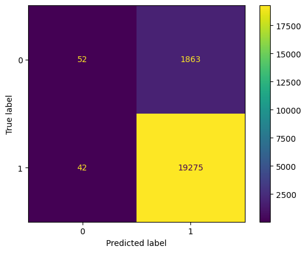

```python
cm_imb_knn_k20 = confusion_matrix(y_test, y_pred)
ConfusionMatrixDisplay(confusion_matrix=cm_imb_knn_k20).plot()

tp, tn, fp, fn = cm_imb_knn_k20[1,1], cm_imb_knn_k20[0,0], cm_imb_knn_k20[0,1], cm_imb_knn_k20[1,0]
spec = round(tn/(tn+fp),3)*100
print(f'Specificity: {spec}%')
```

```python
imb_knn_k2 = KNeighborsClassifier(n_neighbors=2)
imb_knn_k2.fit(X_train, y_train)

y_pred = imb_knn_k2.predict(X_test)
print(f'Accuracy: {round(accuracy_score(y_test, y_pred),4)} | F1: {round(f1_score(y_test, y_pred),4)}')
```

```
Accuracy: 0.815 | F1: 0.8948
```

```
Specificity: 30.8%
```

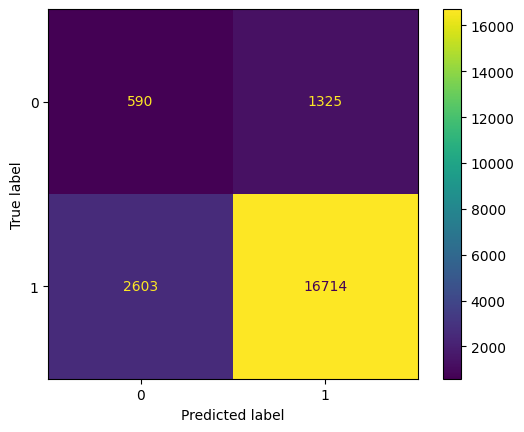

```python
cm_imb_knn_k2 = confusion_matrix(y_test, y_pred)
ConfusionMatrixDisplay(confusion_matrix=cm_imb_knn_k2).plot()

tp, tn, fp, fn = cm_imb_knn_k2[1,1], cm_imb_knn_k2[0,0], cm_imb_knn_k2[0,1], cm_imb_knn_k2[1,0]
spec = round(tn/(tn+fp),3)*100
print(f'Specificity: {spec}%')
```

KNN classifier shows very ineteresting insights. The more neighbors it considers, the more underfitted the model becomes and the more biased towards the majority class it gets. And, since the training set is very imbalanced, the model will better predict the majority class.

This is the proof that an "overfitted" model may be better for capturing the minority class in an imbalanced dataset.

How do `max_depth` and `k` affett **specificity** of, respectively, **Decision Tree** and **KNN** classifiers?

```
Fitting model with 3
Fitting model with 4
Fitting model with 5
Fitting model with 6
Fitting model with 7
Fitting model with 8
Fitting model with 9
Fitting model with 10
Fitting model with 11
Fitting model with 12
Fitting model with 13
Fitting model with 14
Fitting model with 15
Fitting model with 16
Fitting model with 17
Fitting model with 18
Fitting model with 19
Fitting model with 20
Fitting model with 21
Fitting model with 22
Fitting model with 23
Fitting model with 24
Fitting model with 25
Fitting model with 26
Fitting model with 27
Fitting model with 28
Fitting model with 29
Fitting model with 30
Fitting model with 31
Fitting model with 32
Fitting model with 33
Fitting model with 34
Fitting model with None
None generates the following depth: 35
```

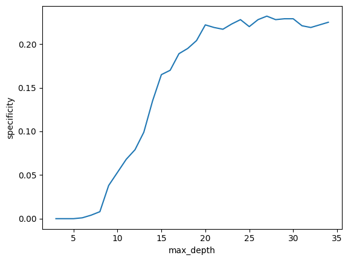

```python
dt_measures = pd.DataFrame(columns=['max_depth', 'specificity'])
parameters = list(range(3, 35)) + [None]

for max_depth in parameters:
    print(f'Fitting model with {max_depth}')
    model = DecisionTreeClassifier(max_depth=max_depth, random_state=42)
    model.fit(X_train, y_train)
    y_pred = model.predict(X_test)
    cm = confusion_matrix(y_test, y_pred)
    tn, fp, fn, tp = cm.ravel()
    spec = round(tn/(tn+fp),3)
    new_row = {'max_depth': max_depth, 'specificity': spec}
    dt_measures.loc[len(dt_measures)] = new_row

    if max_depth == None:
        print(f'None generates the following depth: {model.get_depth()}')


sns.lineplot(x='max_depth', y='specificity', data=dt_measures)
```

```
Fitting model with 1
Fitting model with 2
Fitting model with 3
Fitting model with 4
Fitting model with 5
Fitting model with 6
Fitting model with 7
Fitting model with 8
Fitting model with 9
Fitting model with 10
Fitting model with 11
Fitting model with 12
Fitting model with 13
Fitting model with 14
Fitting model with 15
Fitting model with 16
Fitting model with 17
Fitting model with 18
Fitting model with 19
Fitting model with 20
Fitting model with 21
Fitting model with 22
Fitting model with 23
Fitting model with 24
Fitting model with 25
Fitting model with 26
Fitting model with 27
Fitting model with 28
Fitting model with 29
Fitting model with 30
Fitting model with 31
Fitting model with 32
Fitting model with 33
Fitting model with 34
Fitting model with 35
Fitting model with 36
Fitting model with 37
Fitting model with 38
Fitting model with 39
Fitting model with 40
Fitting model with 41
Fitting model with 42
Fitting model with 43
Fitting model with 44
Fitting model with 45
Fitting model with 46
Fitting model with 47
Fitting model with 48
```

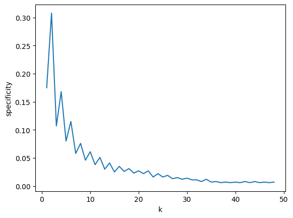

```python
knn_measures = pd.DataFrame(columns=['k', 'specificity'])
parameters = list(range(1, 49))

for k in parameters:
    print(f'Fitting model with {k}')
    model = KNeighborsClassifier(n_neighbors=k, n_jobs=-1)
    model.fit(X_train, y_train)
    y_pred = model.predict(X_test)
    cm = confusion_matrix(y_test, y_pred)
    tn, fp, fn, tp = cm.ravel()
    spec = round(tn/(tn+fp),3)
    new_row = {'k': k, 'specificity': spec}
    knn_measures.loc[len(knn_measures)] = new_row

sns.lineplot(x='k', y='specificity', data=knn_measures)
```

Once we divided an imbalanced dataset to both train and validate our models, the "classical" metrics are not enough to reason about model performance.

This dataset is highly imbalanced, meaning that both test and validation partitions (generated from itself) will have a similar distribution. So, if we use a model that learns to predict everything as positive, when tested in a dataset with similar distribution, it will achieve very good accuracy, F1, ... metrics.

These plots show that, increasing tree depth and decreasing number of neighbors will increase specificity, which is a good indicator of how well the model is capturing the minority class.

## Dealing with the imbalance issue

### Resampling Techniques

These are methods which, respectively, remove examples of the majority class and generate samples for the minority class in order to balance the dataset. They will be applied to the training set only, to avoid data leakage and keep data integrity.

The classical approach to put this in practice is **SMOTE** (Synthetic Minority Over-sampling Technique). This technique generates synthetic samples for any instances of the the minority class by interpolating between existing samples. This is a very popular approach for dealing with imbalanced datasets.

The following SMOTE variants will be applied:

- **SMOTE**: the original technique
- **Random Over-sampling**: generates synthetic samples by randomly selecting a minority class instance and adding noise to it
- **Borderline-SMOTE**: a variant of SMOTE that focuses on the instances that are near the decision boundary
- **ADASYN**: a variant of SMOTE that generates synthetic samples based on the density of the minority class instances, focusing on the regions that are more difficult to learn
- **SVM-SMOTE**: a variant of SMOTE that uses an SVM classifier to identify the instances that are near the decision boundary and generate synthetic samples for them
- **SMOTE-ENN**: combination of over-sampling and under-sampling, which applies SMOTE to the minority class and then removes the samples of majority class that are near the decision boundary
- **SMOTE-TomekLinks**: combination of over-sampling and under-sampling, which applies SMOTE to the minority class and then removes the samples that are near the decision boundary

Due to the high computational cost of TSNE visualization, we will compare the characteristics of resampled datasets using some **Data Complexity Measures**: F1, F2, F3, F4.

```python
def get_data_complexity(X, y):
    return {
        'f1' : round(pbx.f1(X, y),3),
        'f2' : round(pbx.f2(X, y),3),
        'f3' : round(pbx.f3(X, y),3),
        'f4' : round(pbx.f4(X, y),3),
    }
```

```python
def print_target_dist(y, dataset_name):
    print(f"Frequency in {dataset_name} dataset: {y.value_counts()}")
    print(f"Percentage in {dataset_name} dataset: {y.value_counts(normalize=True).round(3)}")
```

#### SMOTE

```python
X_smote, y_smote = SMOTE(random_state=42).fit_resample(X_train, y_train)
print_target_dist(y_smote, 'SMOTE')
```

```
Frequency in SMOTE dataset: health_ins
1    45021
0    45021
Name: count, dtype: int64
Percentage in SMOTE dataset: health_ins
1    0.5
0    0.5
Name: proportion, dtype: float64
```

#### Random Over-sampling

```python
X_random, y_random = RandomOverSampler(random_state=42).fit_resample(X_train, y_train)
print_target_dist(y_random, 'Random Over Sampler')
```

```
Frequency in Random Over Sampler dataset: health_ins
1    45021
0    45021
Name: count, dtype: int64
Percentage in Random Over Sampler dataset: health_ins
1    0.5
0    0.5
Name: proportion, dtype: float64
```

#### Borderline-SMOTE

```python
X_borderline, y_borderline = BorderlineSMOTE(random_state=42).fit_resample(X_train, y_train)
print_target_dist(y_borderline, 'Borderline SMOTE')
```

```
Frequency in Borderline SMOTE dataset: health_ins
1    45021
0    45021
Name: count, dtype: int64
Percentage in Borderline SMOTE dataset: health_ins
1    0.5
0    0.5
Name: proportion, dtype: float64
```

#### ADASYN

```python
X_adasyn, y_adasyn = ADASYN(random_state=42).fit_resample(X_train, y_train)
print_target_dist(y_adasyn, 'ADASYN')
```

```
Frequency in ADASYN dataset: health_ins
0    45508
1    45021
Name: count, dtype: int64
Percentage in ADASYN dataset: health_ins
0    0.503
1    0.497
Name: proportion, dtype: float64
```

#### SVM-SMOTE

```python
X_svmsmote, y_svmsmote = SVMSMOTE(random_state=42).fit_resample(X_train, y_train)
print_target_dist(y_svmsmote, 'SVMSMOTE')
```

```
Frequency in SVMSMOTE dataset: health_ins
1    45021
0    45021
Name: count, dtype: int64
Percentage in SVMSMOTE dataset: health_ins
1    0.5
0    0.5
Name: proportion, dtype: float64
```

#### SMOTE-ENN

```python
X_smoteenn, y_smoteenn = SMOTEENN(random_state=42).fit_resample(X_train, y_train)
print_target_dist(y_smoteenn, 'SMOTEENN')
```

```
Frequency in SMOTEENN dataset: health_ins
0    43806
1    31126
Name: count, dtype: int64
Percentage in SMOTEENN dataset: health_ins
0    0.585
1    0.415
Name: proportion, dtype: float64
```

#### SMOTE-Tomek Links

```python
X_smotetomek, y_smotetomek = SMOTETomek(random_state=42).fit_resample(X_train, y_train)
print_target_dist(y_smotetomek, 'SMOTETomek')
```

```
Frequency in SMOTETomek dataset: health_ins
1    44899
0    44899
Name: count, dtype: int64
Percentage in SMOTETomek dataset: health_ins
1    0.5
0    0.5
Name: proportion, dtype: float64
```

#### Comparison of resampled datasets

```python
datasets = {
    'SMOTE': (X_smote, y_smote),
    'Random Over Sampler': (X_random, y_random),
    'Borderline SMOTE': (X_borderline, y_borderline),
    'ADASYN': (X_adasyn, y_adasyn),
    'SVM-SMOTE': (X_svmsmote, y_svmsmote),
    'SMOTE-ENN': (X_smoteenn, y_smoteenn),
    'SMOTE-Tomek': (X_smotetomek, y_smotetomek),
}

fb_measures = pd.DataFrame([], columns=['dataset', 'f1', 'f2', 'f3', 'f4'])

for dataset, (X, y) in datasets.items():
    print(f'Calculating metrics for {dataset}')
    metrics = get_data_complexity(X, y)
    fb_measures.loc[len(fb_measures)] = {'dataset': dataset, **metrics}

fb_measures
```

```
Calculating metrics for SMOTE
Calculating metrics for Random Over Sampler
Calculating metrics for Borderline SMOTE
Calculating metrics for ADASYN
Calculating metrics for SVM-SMOTE
Calculating metrics for SMOTE-ENN
Calculating metrics for SMOTE-Tomek
```

|  | dataset | f1 | f2 | f3 | f4 |
| --- | --- | --- | --- | --- | --- |
| 0 | SMOTE | 0.817 | 0.895 | 0.996 | 0.996 |
| 1 | Random Over Sampler | 0.829 | 0.895 | 0.996 | 0.996 |
| 2 | Borderline SMOTE | 0.785 | 0.895 | 0.996 | 0.996 |
| 3 | ADASYN | 0.829 | 0.895 | 0.996 | 0.996 |
| 4 | SVM-SMOTE | 0.710 | 0.466 | 0.969 | 0.944 |
| 5 | SMOTE-ENN | 0.689 | 0.877 | 0.994 | 0.993 |
| 6 | SMOTE-Tomek | 0.817 | 0.895 | 0.996 | 0.996 |

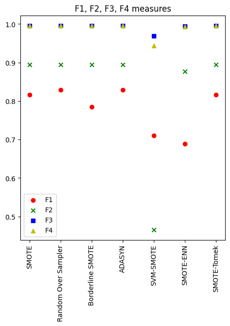

```python
# Plot feature based measures
plt.figure(figsize=(12, 6))
plt.subplot(1, 2, 1)
plt.scatter(fb_measures['dataset'], fb_measures['f1'], color='r', label='F1', marker='o')
plt.scatter(fb_measures['dataset'], fb_measures['f2'], color='g', label='F2', marker='x')
plt.scatter(fb_measures['dataset'], fb_measures['f3'], color='b', label='F3', marker='s')
plt.scatter(fb_measures['dataset'], fb_measures['f4'], color='y', label='F4', marker='^')
plt.xticks(rotation=90)
plt.legend()
plt.title('F1, F2, F3, F4 measures')
plt.show()
```

Remembering the meaning of each measure:

- **F1**: class separability
- **F2**: feature overlap
- **F3**: best single feature
- **F4**: combined feature effectiveness

The objective is to find a good trade-off between high F1 and low F2.

```python
X_train, y_train = X_smote, y_smote
```

### Model (re-)evaluation

```python
# Function to, given the prediction of a model, return its performance metrics
def get_metrics(y_pred):
    cm = confusion_matrix(y_test, y_pred)
    acc = round(accuracy_score(y_test, y_pred),3)
    prec = round(precision_score(y_test, y_pred),3)
    rec = round(recall_score(y_test, y_pred),3)
    f1 = round(f1_score(y_test, y_pred),3)
    tn, fp, fn, tp = cm.ravel()
    spec = round(tn / (tn+fp),3)
    gmean = round(np.sqrt(rec*spec),3)
    return {'accuracy': acc, 'precision': prec, 'recall': rec, 'f1': f1, 'specificity': spec, 'gmean': gmean, 'cm': cm}
```

```python
def plot_measures(measures):
    parameters = measures.iloc[:,0]
    accuracy = measures.iloc[:,1]
    precision = measures.iloc[:,2]
    recall = measures.iloc[:,3]
    f1 = measures.iloc[:,4]
    spec = measures.iloc[:,5]
    gmean = measures.iloc[:,6]

    sns.lineplot(x=parameters, y=accuracy, label='accuracy')
    sns.lineplot(x=parameters, y=precision, label='precision')
    sns.lineplot(x=parameters, y=recall, label='recall')
    sns.lineplot(x=parameters, y=f1, label='f1')
    sns.lineplot(x=parameters, y=spec, label='specificity')
    sns.lineplot(x=parameters, y=gmean, label='gmean')
```

```python
models = pd.DataFrame(columns=['model', 'accuracy', 'precision', 'recall', 'f1', 'specificity', 'gmean', 'cm'])
```

```
Fitting model with 1
Fitting model with 2
Fitting model with 3
Fitting model with 4
Fitting model with 5
Fitting model with 6
Fitting model with 7
Fitting model with 8
Fitting model with 9
Fitting model with 10
Fitting model with 11
Fitting model with 12
Fitting model with 13
Fitting model with 14
Fitting model with 15
Fitting model with 16
Fitting model with 17
Fitting model with 18
Fitting model with 19
Fitting model with 20
Fitting model with 21
Fitting model with 22
Fitting model with 23
Fitting model with 24
Fitting model with 25
Fitting model with 26
Fitting model with 27
Fitting model with 28
Fitting model with 29
Fitting model with None
None generates the following depth: 42
```

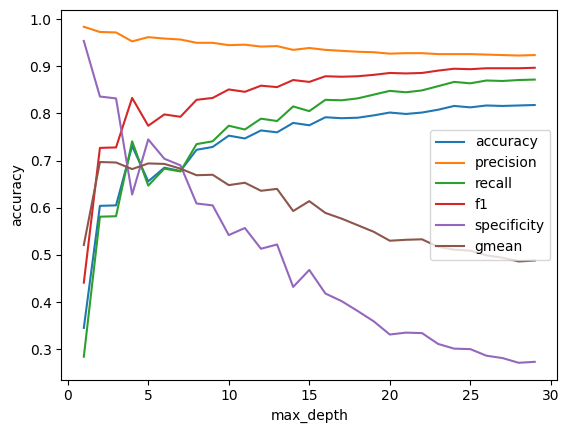

```python
dt_measures = pd.DataFrame(columns=['max_depth', 'accuracy', 'precision', 'recall', 'f1', 'specificity', 'gmean', 'cm'])
parameters = list(range(1, 30)) + [None]

for max_depth in parameters:
    print(f'Fitting model with {max_depth}')
    model = DecisionTreeClassifier(max_depth=max_depth)
    model.fit(X_train, y_train)
    y_pred = model.predict(X_test)
    measures = get_metrics(y_pred)
    new_row = {'max_depth': max_depth, **measures}
    dt_measures.loc[len(dt_measures)] = new_row

    if max_depth == None:
        print(f'None generates the following depth: {model.get_depth()}')

plot_measures(dt_measures)
```

```python
# Choose decision tree with max_depth = 5
row = dt_measures[dt_measures['max_depth'] == 5]
models.loc[len(models)] = {'model': 'Decision Tree', **row.iloc[0,1:]}
models
```

|  | model | accuracy | precision | recall | f1 | specificity | gmean | cm |
| --- | --- | --- | --- | --- | --- | --- | --- | --- |
| 0 | Decision Tree | 0.656 | 0.962 | 0.647 | 0.774 | 0.745 | 0.694 | [[1427, 488], [6814, 12503]] |

```
Fitting model with 3
Fitting model with 4
Fitting model with 5
Fitting model with 6
Fitting model with 7
Fitting model with 8
Fitting model with 9
Fitting model with 10
Fitting model with 11
Fitting model with 12
Fitting model with 13
Fitting model with 14
Fitting model with 15
Fitting model with 16
Fitting model with 17
Fitting model with 18
Fitting model with 19
Fitting model with 20
Fitting model with 21
Fitting model with 22
Fitting model with 23
Fitting model with 24
Fitting model with 25
Fitting model with 26
Fitting model with 27
Fitting model with 28
Fitting model with 29
Fitting model with 30
Fitting model with 31
Fitting model with 32
Fitting model with 33
Fitting model with 34
```

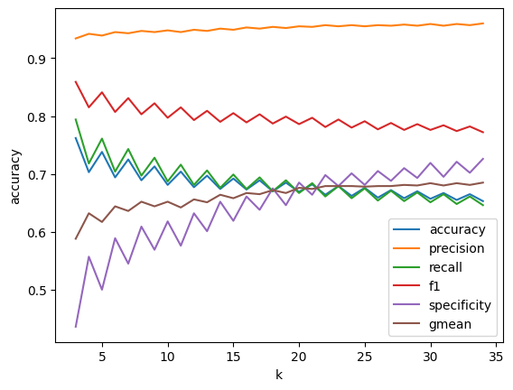

```python
knn_measures = pd.DataFrame(columns=['k', 'accuracy', 'precision', 'recall', 'f1', 'specificity', 'gmean', 'cm'])
parameters = list(range(3, 35))

for k in parameters:
    print(f'Fitting model with {k}')
    model = KNeighborsClassifier(n_neighbors=k, n_jobs=-1)
    model.fit(X_train, y_train)
    y_pred = model.predict(X_test)
    measures = get_metrics(y_pred)
    new_row = {'k': k, **measures}
    knn_measures.loc[len(knn_measures)] = new_row

plot_measures(knn_measures)
```

```python
row = knn_measures[knn_measures['k'] == 21]
models.loc[len(models)] = {'model': 'KNN', **row.iloc[0,1:]}
models
```

|  | model | accuracy | precision | recall | f1 | specificity | gmean | cm |
| --- | --- | --- | --- | --- | --- | --- | --- | --- |
| 0 | Decision Tree | 0.656 | 0.962 | 0.647 | 0.774 | 0.745 | 0.694 | [[1427, 488], [6814, 12503]] |
| 1 | KNN | 0.682 | 0.954 | 0.684 | 0.797 | 0.664 | 0.674 | [[1271, 644], [6102, 13215]] |

```python
def plot_models_perf(results):
    melted = results.melt(id_vars="model", value_vars=["accuracy", "precision", "recall", "f1", "specificity"],
                        var_name="measure", value_name="value")

    plt.figure(figsize=(20, 7))
    sns.barplot(data=melted, x="model", y="value", hue="measure", palette="deep")
    plt.title("Model Performance Comparison", fontsize=16)
    plt.xlabel("Model", fontsize=20)
    plt.ylabel("Value", fontsize=20)
    plt.xticks(fontsize=20)
    plt.yticks(fontsize=20)
    plt.legend(title="Measure", fontsize=20, title_fontsize=20)
    plt.tight_layout()
    plt.show()
```

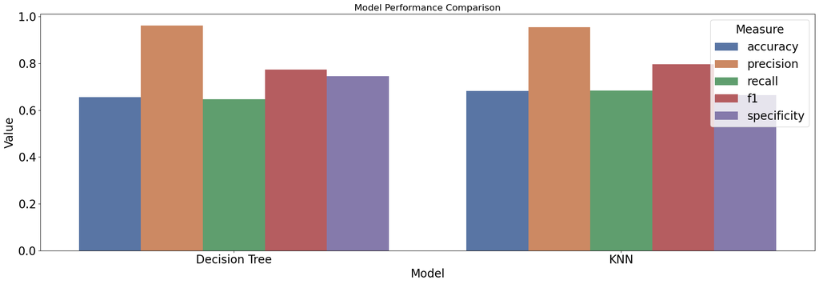

```python
plot_models_perf(models)
```

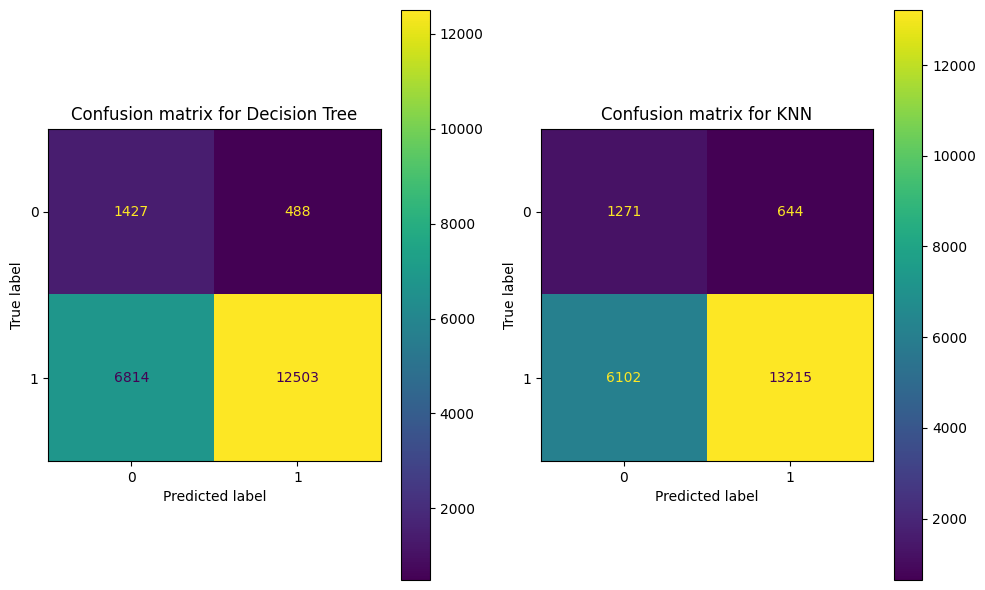

```python
num_models = len(models)
fig, axes = plt.subplots(1, num_models, figsize=(5 * num_models, 6))
for i, (index, row) in enumerate(models.iterrows()):
    model = row['model']
    cm = row['cm']
    ax = axes[i] if num_models > 1 else axes
    ConfusionMatrixDisplay(confusion_matrix=cm).plot(ax=ax)
    ax.set_title(f'Confusion matrix for {model}')

plt.tight_layout()
plt.show()
```

After rebalancing techniques, our models became much more capable of capturing negatives cases (minority class). Specificity increased to around 70%. However, the "classical" performance metrics decreased a bit but this was expected, since the validation set does now follow the same distribution as the training set (imbalanced vs balanced).